# Analysis of learning via the IAT using race stimuli

Ian Hussey

## Hypotheses

H1: Completing an IAT serves to train attitudes as well as test them. Participants who complete a race IAT will demonstrate more negative implicit evaluations of the outgroup (black people) on the SCIAT than participants who completed a control (flowers-insects) IAT.

H2: Completing an IAT serves to train attitudes as well as test them. Participants who complete a race IAT will demonstrate more negative self-reported evaluations of the outgroup (black people) on the ratings than participants who completed a control (flowers-insects) IAT.

```r
# dependencies
library(tidyverse)
library(psych)
library(afex)
library(effsize)
library(weights)  # for rd(), a round() alternative
library(plotrix)  # for std.error
```

# Descriptive statistics

## All participants

Descriptive data for sample.

```r
setwd(params$location_of_data)
```

```
The working directory was changed to /Users/Ian/Dropbox/Work/Projects/Analogy/1 analogical learning via IAT with known stimuli/Experiment 1/data inside a notebook chunk. The working directory will be reset when the chunk is finished running. Use the knitr root.dir option in the setup chunk to change…
```

```r
data_df <-
  read.csv("processed data/wide all tasks data.csv") %>%
  mutate(gender = as.factor(gender))
colnames(data_df)
```

```
 [1] "participant"                        "condition"
 [3] "IAT_condition"                      "block_order"
 [5] "task_order"                         "gender"
 [7] "age"                                "mean_rating"
 [9] "IAT_D1"                             "IAT_mean_RT"
[11] "IAT_perc_acc"                       "IAT_exclude_based_on_fast_trials"
[13] "SCIAT_D1"                           "SCIAT_mean_RT"
[15] "SCIAT_perc_acc"                     "SCIAT_exclude_based_on_fast_trials"
[17] "modern_racism_scale_total"
```

```r
data_df %>% dplyr::count(gender)
```

| gender | n |
| --- | --- |
| 24 | 1 |
| 33 | 1 |
| female | 48 |
| feminine | 1 |
| male | 101 |
| nonbinary | 1 |

```r
data_df %>%
  dplyr::select(age) %>%
  psych::describe(fast = TRUE,  # subset of descriptive stats
                  ranges = FALSE,
                  trim = 0) %>%
  dplyr::select(-vars, -se)
```

```
      n  mean    sd
age 153 31.93 11.03
```

## Sample descriptive statistics

```r
passers_df <-
  data_df %>%
  filter(IAT_exclude_based_on_fast_trials == FALSE & SCIAT_exclude_based_on_fast_trials == FALSE)
passers_df %>% dplyr::count(IAT_condition)
```

| IAT_condition | n |
| --- | --- |
| Flowers-Insects IAT | 75 |
| Race IAT | 71 |

```r
passers_df %>%
  dplyr::select(IAT_mean_RT,
                IAT_perc_acc,
                SCIAT_mean_RT,
                SCIAT_perc_acc) %>%
  psych::describe(fast = TRUE,  # subset of descriptive stats
                  ranges = FALSE,
                  trim = 0) %>%
  dplyr::select(-vars, -se)
```

```
                 n   mean     sd
IAT_mean_RT    146 828.19 187.70
IAT_perc_acc   146   0.93   0.07
SCIAT_mean_RT  146 692.54 136.30
SCIAT_perc_acc 146   0.93   0.05
```

# H1: Differences in IAT effects between contrast pair conditions

## Outlier removal

```r
# get data
setwd(params$location_of_data)
# exclude participants who had more than 10% of trials in less than 300ms, and make variables factors
SCIAT_data <-
  read.csv("processed data/long SCIAT data.csv") %>%
  mutate(participant = as.factor(participant),
         block = as.factor(ifelse(block == "compatible", "black-positive",
                        ifelse(block == "incompatible", "black-negative", NA))),
         IAT_condition = as.factor(IAT_condition)) %>%
  filter(IAT_exclude_based_on_fast_trials == FALSE & SCIAT_exclude_based_on_fast_trials == FALSE)
# exclude outliers
SCIAT_data_outliers_removed <-
  SCIAT_data %>%
  schoRsch::outlier(dv = "rt",  # exclude individual RTs that are greater than 2.5 SD from the mean
                    todo="elim",
                    upper.z = 2.5,
                    lower.z = -2.5)
```

```
[1] "Function outlier() has screened 20440 trial(s) in total. Of these were 113 trial(s) identified as outliers (0.55%)."
```

## Descriptive statistics

```r
SCIAT_summary_data <-
  SCIAT_data_outliers_removed %>%
  group_by(IAT_condition, block) %>%
  dplyr::summarize(mean_rt = round(mean(rt), 0),
                   sd_rt = round(sd(rt), 0),
                   se_rt = round(std.error(rt), 2))
SCIAT_summary_data
```

| IAT_condition | block | mean_rt | sd_rt | se_rt |
| --- | --- | --- | --- | --- |
| Flowers-Insects IAT | black-negative | 671 | 260 | 3.59 |
| Flowers-Insects IAT | black-positive | 664 | 265 | 3.67 |
| Race IAT | black-negative | 677 | 260 | 3.70 |
| Race IAT | black-positive | 688 | 283 | 4.02 |

## Plots

```r
# apa theme for all plots
apatheme <-
  theme_bw() +
  theme(panel.grid.major = element_blank(),
        panel.grid.minor = element_blank(),
        panel.background = element_blank(),
        panel.border = element_blank(),
        #text = element_text(family='Arial'),  # doesn't play nice with knittr
        legend.title = element_blank(),
        legend.position = c(.9,.9),
        axis.line.x = element_line(color='black'),
        axis.line.y = element_line(color='black'))
# add a combined condition*IAT block variable for plotting
SCIAT_data_outliers_removed <-
  SCIAT_data_outliers_removed %>%
  mutate(exp_factor = paste(IAT_condition, block, sep = "_"))
```

### Outlier removal

Distribution of RTs before and after trimming outliers.

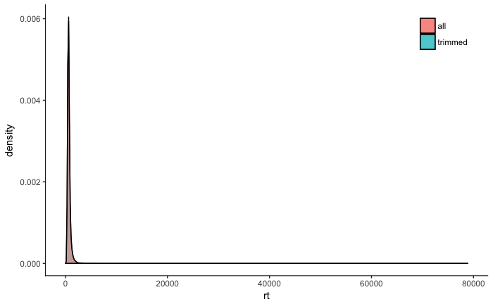

```r
ggplot(data = SCIAT_data_outliers_removed, aes(rt, fill = "trimmed")) +
  geom_density(alpha=0.50) +
  geom_density(data = SCIAT_data,
               aes(rt, fill = "all"),
               alpha=0.50) +
  apatheme
```

### Density plot split by factor

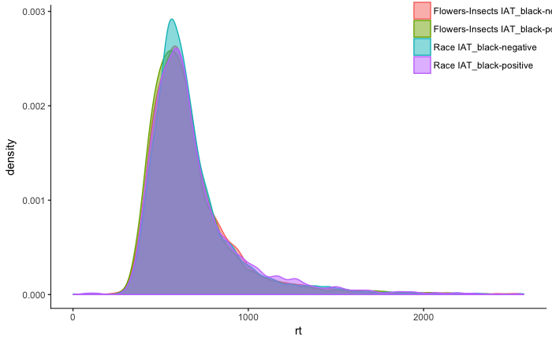

```r
ggplot(SCIAT_data_outliers_removed,
       aes(rt, colour = exp_factor, fill = exp_factor)) +
  geom_density(alpha=0.50) +
  apatheme
```

### Distribution and inference plot

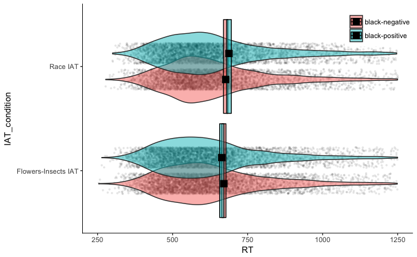

```r
ggplot(data = SCIAT_summary_data,
       aes(x = IAT_condition, y = mean_rt, fill = block)) +
  geom_point(data = SCIAT_data_outliers_removed,
             aes(x = IAT_condition, y = rt, fill = block),
             size = 1,
             shape = 16,
             alpha = 0.1,
             position = position_jitterdodge(dodge.width = .5)) +
  geom_violin(data = SCIAT_data_outliers_removed,
              aes(x = IAT_condition, y = rt, fill = block),
              alpha = 0.5,
              position = position_dodge(width = .5)) +
  geom_crossbar(aes(ymax = mean_rt + (1.96*se_rt),
                    ymin = mean_rt + (-1.96*se_rt)),
                alpha = 0.5,
                fatten = 0) +
  geom_point(size = 4,
             shape = 15,
             position = position_dodge(width = .5)) +
  apatheme +
  ylab("RT") +
  ylim(250,1250) +
  coord_flip()
```

## Preregistered hypothesis test

Frequentist mixed linear effects model with participant as a random effect. Entering participant as a random effect acknowledges the non-independence of the multiple data points for each participants. Specifically, allowing for a random intercept allows for differences in general responding speed between participants, therefore controlling for age, IQ, etc., as the *D*1 score does. Using a LMM here therefore serves a dual purpose of controlling for within-subject variation (traditionally served by *D*1 scoring) and between subject analysis, while making use of all data points rather than collapsing the IAT’s 80 RTs into just one score.

Two important considerations:

1. Production of *p* values (over LRs, etc.) is contentious, but cite the following as recent evidence for the use of Kenward Roger method estimation: http://link.springer.com/article/10.3758%2Fs13428-016-0809-y
2. No effect sizes are produced due to contention over how to use the random factor error. See http://stats.stackexchange.com/questions/95054/how-to-get-an-overall-p-value-and-effect-size-for-a-categorical-factor-in-a-mi

The model is `rt ~ block * IAT_condition + modern_racism_scale_total + (1 | participant)`. That is, RT is predicted by the interaction between SCIAT block and training IAT condition, after controlling for differences in racism, and while allowing for participants to have a random intercept (i.e., variable mean RT).

```r
# Check that variables that should be factors are indeed factors
sapply(SCIAT_data_outliers_removed, class)
```

```
                       participant                              block                            trial_n
                          "factor"                           "factor"                          "integer"
                                rt                           accuracy                      IAT_condition
                         "integer"                          "integer"                           "factor"
                       block_order                         task_order                             gender
                          "factor"                           "factor"                           "factor"
                               age          modern_racism_scale_total   IAT_exclude_based_on_fast_trials
                         "integer"                          "integer"                          "logical"
SCIAT_exclude_based_on_fast_trials                            outlier                            zscores
                         "logical"                          "numeric"                          "numeric"
                        exp_factor
                       "character"
```

```r
# LME analysis
model_1 <- afex::mixed(rt ~ block * IAT_condition + modern_racism_scale_total + (1 | participant),
                       contrasts = TRUE,
                       data = SCIAT_data_outliers_removed,
                       type = 3,
                       method = "KR",
                       progress = TRUE,
                       return = "mixed")
```

[output not shown]

# H2: Differences in self-reported ratings between contrast pair conditions

## Descriptive statistics

```r
# get data
setwd(params$location_of_data)
```

```
The working directory was changed to /Users/Ian/Dropbox/Work/Projects/Analogy/1 analogical learning via IAT with known stimuli/Experiment 1/data inside a notebook chunk. The working directory will be reset when the chunk is finished running. Use the knitr root.dir option in the setup chunk to change…
```

```r
# exclude participants who had more than 10% of trials in less than 300ms, and make variables factors
ratings_data <-
  read.csv("processed data/long ratings data.csv") %>%
  mutate(participant = as.factor(participant),
         IAT_condition = as.factor(IAT_condition)) %>%
  filter(IAT_exclude_based_on_fast_trials == FALSE & SCIAT_exclude_based_on_fast_trials == FALSE)
ratings_summary_data <-
  ratings_data %>%
  group_by(IAT_condition) %>%
  dplyr::summarize(mean_rating = round(mean(rating), 2),
                   sd_rating = round(sd(rating), 2),
                   se_rating = round(std.error(rating), 2))
ratings_summary_data
```

| IAT_condition | mean_rating | sd_rating | se_rating |
| --- | --- | --- | --- |
| Flowers-Insects IAT | 4.26 | 1.03 | 0.05 |
| Race IAT | 4.21 | 1.14 | 0.06 |